# ModelingAndPerformanceEvaluations

Mehdi Salmani Jelodar - BCG

November 14, 2017

## Random Forest Model Estimation

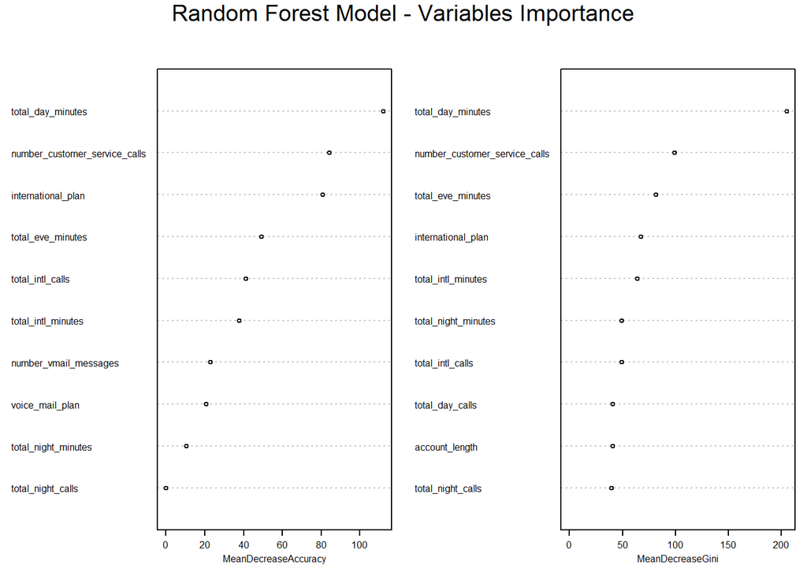

```r
# Random Forest - Estimate Model
set.seed(123) # Setting seed to ensure consistency of results in each run
RandomForest_Fit <- randomForest(x = churnTrain_x, y = churnTrain_y, importance = TRUE, ntree = 600)

# Random Forest - Predictions and confusion matrix for test data set
RandomForest_Test_Predictions <- predict(object = RandomForest_Fit, newdata = churnTest_x, type = "response")
RandomForest_Confusion_Matrix <- table(RandomForest_Test_Predictions, churnTest_y)
RandomForest_Confusion_Matrix_Perc <- t(apply(RandomForest_Confusion_Matrix,1,"/",y_Test_Table))

# Random Forest - Stores confusion matrix for comparison
Num_models <- Num_models + 1
Confusion_Matrix[[Num_models]] <- RandomForest_Confusion_Matrix_Perc
Models_specs[Num_models] <- "Random Forest Model"

# Random Forest - Plot error rate (total and for churn yes/no) and print confusion matrix
varImpPlot(RandomForest_Fit, sort=TRUE, cex =0.5, n.var = 10, main = "Random Forest Model - Variables Importance")
```

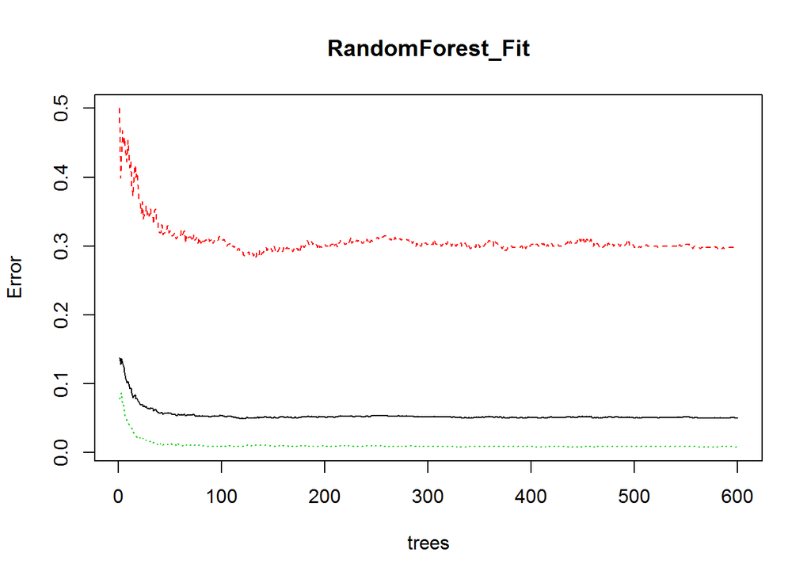

```r
plot(RandomForest_Fit)
```

```r
print(RandomForest_Confusion_Matrix_Perc)
```

```
##                              churnTest_y
## RandomForest_Test_Predictions       yes          no
##                           yes 0.6785714 0.002079002
##                           no  0.3214286 0.997920998
```

## Neural Networks Model Estimation

### Data Preparation

The data need to be transformed in order to effectively train a neural network. More specifically:

- numerical variables should be standardized in the 0-1 range
- binary variables espressed in terms of “yes”/“no” should be converted to a numeric binary
- categorical variables (e.g. states, zip codes, etc.) should be transformed in binary variables, where each variables is a binary representation of one of the categories

```r
# Creation of binary  variables for the three area codes in the data set
# Area code datafames initialization
Area_code_Train <- data.frame(matrix(ncol = 3, nrow = nrow(churnTrain)))
names(Area_code_Train) <- c("A_408","A_415","A_510")
Area_code_Test <- data.frame(matrix(ncol = 3, nrow = nrow(churnTest)))
names(Area_code_Test) <- c("A_408","A_415","A_510")
# Area code datafames fill with binary data
Area_code_Train[,1] = ifelse(churnTrain[,3]=='area_code_408',1,0)
Area_code_Train[,2] = ifelse(churnTrain[,3]=='area_code_415',1,0)
Area_code_Train[,3] = ifelse(churnTrain[,3]=='area_code_510',1,0)
Area_code_Test[,1] = ifelse(churnTest[,3]=='area_code_408',1,0)
Area_code_Test[,2] = ifelse(churnTest[,3]=='area_code_415',1,0)
Area_code_Test[,3] = ifelse(churnTest[,3]=='area_code_510',1,0)

# Create train and test data sets for neural netwoek input variables
# Drop "state", "area code" and "churn" variables, as well as "charge" variables with perfect positive correlation
var.out.nn <- c("state", "area_code", "churn", "total_day_charge", "total_eve_charge",  "total_night_charge",  "total_intl_charge")
var.out.nn.index <- which(names(churnTest) %in% var.out.nn)
churnTrain_NN_x <- churnTrain[,-var.out.nn.index]
churnTest_NN_x <- churnTest[,-var.out.nn.index]
# Move binary variables to the right of the data frames
churnTrain_NN_x <- churnTrain_NN_x[c(1,4,5,6,7,8,9,10,11,12,2,3)]
churnTest_NN_x <- churnTest_NN_x[c(1,4,5,6,7,8,9,10,11,12,2,3)]

# Standardize numeric variables
# Retrieves mins and max for the numeric columns
max_ChurnTrain <- apply(churnTrain_NN_x[,1:10], 2, max)
min_ChurnTrain <- apply(churnTrain_NN_x[,1:10], 2, min)
max_ChurnTest <- apply(churnTest_NN_x[,1:10], 2, max)
min_ChurnTest <- apply(churnTest_NN_x[,1:10], 2, min)

# Standardize numeric variables in the 0 - 1 range
churnTrain_NN_x[,1:10] <- as.data.frame(scale(churnTrain_NN_x[,1:10], center = min_ChurnTrain, scale = max_ChurnTrain - min_ChurnTrain))
churnTest_NN_x[,1:10] <- as.data.frame(scale(churnTest_NN_x[,1:10], center = min_ChurnTest, scale = max_ChurnTest - min_ChurnTest))

# Convert binary variables to 0 - 1
churnTrain_NN_x[,11] = ifelse(churnTrain_NN_x[,11]=='yes',1,0)
churnTrain_NN_x[,12] = ifelse(churnTrain_NN_x[,12]=='yes',1,0)
churnTest_NN_x[,11] = ifelse(churnTest_NN_x[,11]=='yes',1,0)
churnTest_NN_x[,12] = ifelse(churnTest_NN_x[,12]=='yes',1,0)

# Create target variable as 0 - 1 binary
churnTrain_NN_y = ifelse(churnTrain_y=='yes',1,0)
churnTest_NN_y = ifelse(churnTest_y=='yes',1,0)

# Create the final training and test data sets
churnTrain_NN_x <- cbind(churnTrain_NN_x, Area_code_Train, churnTrain_NN_y)
churnTest_NN_x <- cbind(churnTest_NN_x, Area_code_Test, churnTest_NN_y)
colnames(churnTrain_NN_x)[16] <- "y"
colnames(churnTest_NN_x)[16] <-"y"
```

The training of a neural network is an iterative process where the estimation parameters are progressively tweaked. After defining the reference formula, a data structure is created to store the outcome of each iteration.

```r
# Create the formula
input_variables <-colnames(churnTrain_NN_x)[1:12]
formula_NN <- as.formula(paste("y ~",paste(input_variables, collapse = " + ")))

# Create the data structure to store neural networks information
Neural_Networks = list() # List where the nn objects are stored
NN_Structure = list()    # List with the information on the nn layers
NN_Test_Predictions = list() # List to store the predictions produced with the different neural networks
NN_Confusion_Matrix = list() # List of confusion matrices with number of predictions
NN_Confusion_Matrix_Perc = list() # List of confusion matrices with percentages
NN_Index <- 0
```

```r
# Training of neural networks with one hidden layer
for (hidden1 in 2:4){
  NN_Index <- NN_Index + 1
  NN_Structure[[NN_Index]] <- c(hidden1,0)
  Neural_Networks[[NN_Index]] <- neuralnet(formula_NN,data=churnTrain_NN_x,hidden=c(hidden1),linear.output= FALSE, rep = 1, algorithm = "backprop", learningrate = 0.01, stepmax = 1e6)
  print(NN_Index)
  print(Neural_Networks[[NN_Index]])
  }
```

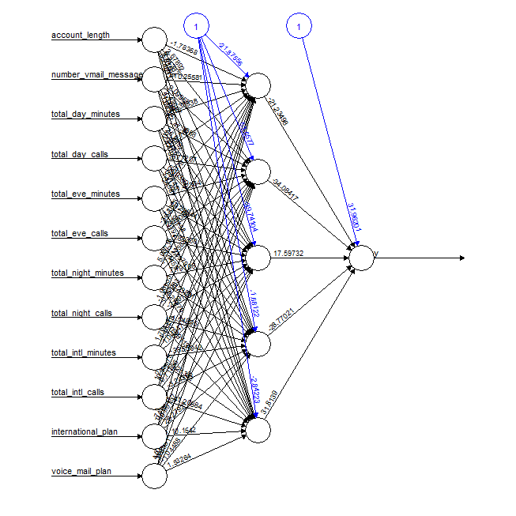

Neural Network with Five Nodes

```r
plot(Neural_Networks[[4]], cex=0.5)
```

```r
# Generate predictions and cross-validation stats for the neural networks successfully trained
load(file="NN_Churn.RData") #Load the data on the Neural Networks structure

for (j in 1:5){
        # Generate Predictions
        NN_Test_Predictions[[j]] <- compute(Neural_Networks[[j]], churnTest_NN_x[,1:12])$net.result
        NN_Test_Predictions[[j]] <- ifelse(NN_Test_Predictions[[j]]>0.5,"yes","no")
        # Compute Confusion Matrix
        NN_Confusion_Matrix[[j]] <- table(NN_Test_Predictions[[j]], churnTest_y)
        NN_Confusion_Matrix_Perc[[j]] <- t(apply(NN_Confusion_Matrix[[j]],1,"/",y_Test_Table))
        NN_Confusion_Matrix_Perc[[j]] <- NN_Confusion_Matrix_Perc[[j]][c(2,1),]
        # Store confusion matrix for comparison with other models
        Num_models <- Num_models + 1
        Confusion_Matrix[[Num_models]] <- NN_Confusion_Matrix_Perc[[j]]
        Models_specs[Num_models] <- paste("Neural Network - ",NN_Structure[[j]][1]," Nodes")
        print(Models_specs[Num_models])
        print(Confusion_Matrix[Num_models])
}
```

```
## [1] "Neural Network -  2  Nodes"
## [[1]]
##      churnTest_y
##             yes         no
##   yes 0.5535714 0.01455301
##   no  0.4464286 0.98544699
##
## [1] "Neural Network -  3  Nodes"
## [[1]]
##      churnTest_y
##             yes         no
##   yes 0.5446429 0.00970201
##   no  0.4553571 0.99029799
##
## [1] "Neural Network -  4  Nodes"
## [[1]]
##      churnTest_y
##             yes          no
##   yes 0.5848214 0.002772003
##   no  0.4151786 0.997227997
##
## [1] "Neural Network -  5  Nodes"
## [[1]]
##      churnTest_y
##         yes          no
##   yes 0.625 0.001386001
##   no  0.375 0.998613999
##
## [1] "Neural Network -  6  Nodes"
## [[1]]
##      churnTest_y
##           yes          no
##   yes 0.59375 0.002772003
##   no  0.40625 0.997227997
```

There is the possibility to improve the performance of the 5-node Neural Network by fine tuning the churn threshold decision criteria.

For example, the threshold for deciding between “churn” and “no churn” can be selected in order to optimize the trade-off between True and False positives.

```
## [1] "Neural Network - 5 Nodes - Optimized"
```

```
## [[1]]
##      churnTest_y
##             yes         no
##   yes 0.6517857 0.01940402
##   no  0.3482143 0.98059598
```

```r
#Select as source predictions the Random Forest, and the Neural Network 5 nodes with 75% True Positives, 81% True Negatives
Source_Predictions <- as.data.frame(cbind(RandomForest_Test_Predictions, NN_Test_Predictions_bin[[100]]))
Source_Predictions[,1] = ifelse(Source_Predictions[,1]==1,1,0)
Source_Predictions[,2] = ifelse(Source_Predictions[,2]=="yes",1,0)
colnames(Source_Predictions) <- c("Random Forest",  "NN 5 Nodes")
churnTest_y_Num = ifelse(churnTest_y=="no",0,1)
```

## Conclusions

The *Random Forest* model has shown the best performance - as an individual model - when evaluated against the test data set. The *Neural Network* performance could be further improved by either fine tuning the training parameters or modifying the network structure.

```
##                                      True Pos False Neg False Pos True Neg
## Random Forest Model                     0.679     0.321     0.002    0.998
## Neural Network -  2  Nodes              0.554     0.446     0.015    0.985
## Neural Network -  3  Nodes              0.545     0.455     0.010    0.990
## Neural Network -  4  Nodes              0.585     0.415     0.003    0.997
## Neural Network -  5  Nodes              0.625     0.375     0.001    0.999
## Neural Network -  6  Nodes              0.594     0.406     0.003    0.997
## Neural Network - 5 Nodes - Optimized    0.652     0.348     0.019    0.981
```

Both the *ROC curve* chart and the *Area Under the Curve (AUC)* stats confirm the *Random Forest* model as better performance in predicting churn:

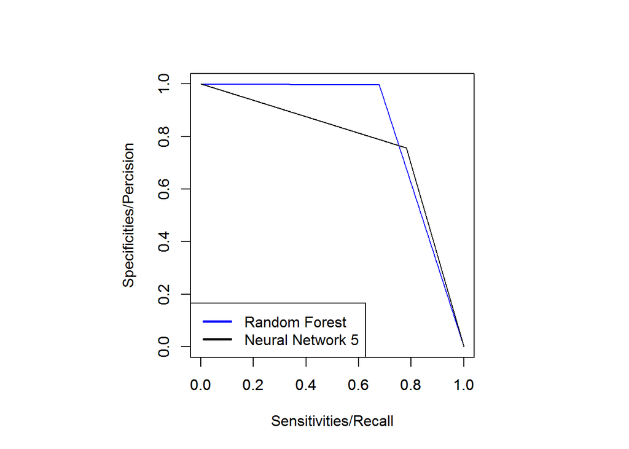

```r
# Compute ROC curve stats
RandomForest_ROC <- roc(response = churnTest_y_Num, predictor = Source_Predictions[,1])
NN5_ROC <- roc(response = churnTest_y_Num, predictor = Source_Predictions[,2])

# Plot AUC curves- for more info about recall and percision please check: https://en.wikipedia.org/wiki/Precision_and_recall
par(pty="s")
plot(RandomForest_ROC$sensitivities,RandomForest_ROC$specificities, col = "blue", type="l",asp=1,xlab="",ylab="")
par(new=TRUE)
plot(NN5_ROC$sensitivities,NN5_ROC$specificities, col = "black", type="l",asp=1,xlab="Sensitivities/Recall",ylab="Specificities/Percision")

legend(x = "bottomleft", c("Random Forest", "Neural Network 5"), lty=c(1,1), lwd=c(2.5,2.5),col=c("blue","black"))
```

```r
# Print AUC stats
print(RandomForest_ROC$auc)
```

```
## Area under the curve: 0.8382
```

```r
print(NN5_ROC$auc)
```

```
## Area under the curve: 0.7693
```